# Analiza ataków terrorystycznych w latach 1970-2021

Katarzyna Zyśko

1)Cel projektu

Celem projektu jest przeprowadzenie szczegółowej analizy ataków terrorystycznych w latach 1970-2021, ze szczególnym uwzględnieniem podziału na kontynenty, regiony, metody ataków, liczbę ataków, liczbę ofiar, podział wiekowy ofiar oraz analizy według dekad. Głównym celem jest zidentyfikowanie wzorców i tendencji oraz zrozumienie specyfiki ataków terrorystycznych w różnych obszarach, okresach czasu i wykorzystywanych metodach.

W projekcie zostały uwzględnione następujące zmienne:

**1.Age-wiek:**

-Death Age 1-5 - wiek od 1-5 lat

-Death Age 6-10 - wiek od 6-10 lat

-Death Age 11-20 - wiek od 11-20 lat

-Death Age 21-50 - wiek od 21-50 lat

-Death Age 51-99 - wiek od 51-99 lat

-Death Age 100 - wiek 100 lat

**2.Attack type-metoda ataku:**

-Arrmed assault-Napaść z bronią w ręku

-Assassination-Zamach

-Bombing explosion-Eksplozja bombowa

-Facility infrastructure attack-Atak na infrastrukturę obiektu

-Hostage,taking,kidnapping-Uprowadzenie,porwanie

-Hijacking-Porwanie środka tranportu

**3.Region-kontynent:**

-Africa-Afryka

-Europe-Europa

-Asia-Azja

-Americas-Ameryka

-Oceania-Oceania

**4.Subregion-region:**

-Eastern Asia- Azja Wschodnia

-Central Asia- Azja Środkowa

-Western Europe- Europa Zachodnia

-Northern America- Ameryka Północna

-Southern Europe- Europa Południowa

-Eastern Europe- Europa Wschodnia

-Northern Europe- Europa Północna

-Northern Africa- Afryka Północna

-South-eastern Asia- Południowo-wschodnia Azja

-Latin-America and the Carribean- Ameryka Łacińska i Karaiby

-Sub-Saharan Africa- Afryka Subsaharyjska

-Western Asia- Azja Zachodnia

-Southern Asia- Azja Południowa

2)Zakres analizy

Analiza będzie obejmować podział na kontynenty, regiony, metody ataków, analizę liczby ataków, liczby ofiar, podział wiekowy ofiar oraz analizę według dekad.

**Analiza Przestrzenna:**

Jak zmieniała się liczba ataków terrorystycznych w różnych regionach i subregionach na przestrzeni lat?

Które regiony/subregiony doświadczyły największego wzrostu lub spadku liczby ataków?

**Charakterystyka Ataków:**

Jakie były najczęstsze metody przeprowadzania ataków terrorystycznych?

**Skutki Ataków:**

Jak rozkładały się skutki ataków terrorystycznych, z uwzględnieniem liczby ofiar, w poszczególnych krajach, regionach i subregionach?

3)Źródło danych

Dane zostały pobrane z platformy Kaggle, a dokładnie z “Terrorist Attacks Data Since 1970-2023”. Zbiór danych zawiera informacje o atakach terrorystycznych od roku 1970 do 2021. Warto zaznaczyć, że do tej bazy danych zostały dodane niektóre informacje z innych źródeł w celu uzyskania pełniejszego obrazu zjawiska ataków terrorystycznych.

4)Przygotowanie danych

Dane zostały przygotowane, uwzględniając konieczne przekształcenia, usunięcie duplikatów i brakujących wartości, a także stworzenie agregacji danych na poziomie kontynentów, regionów, dekad oraz metod ataków.

5)Analiza

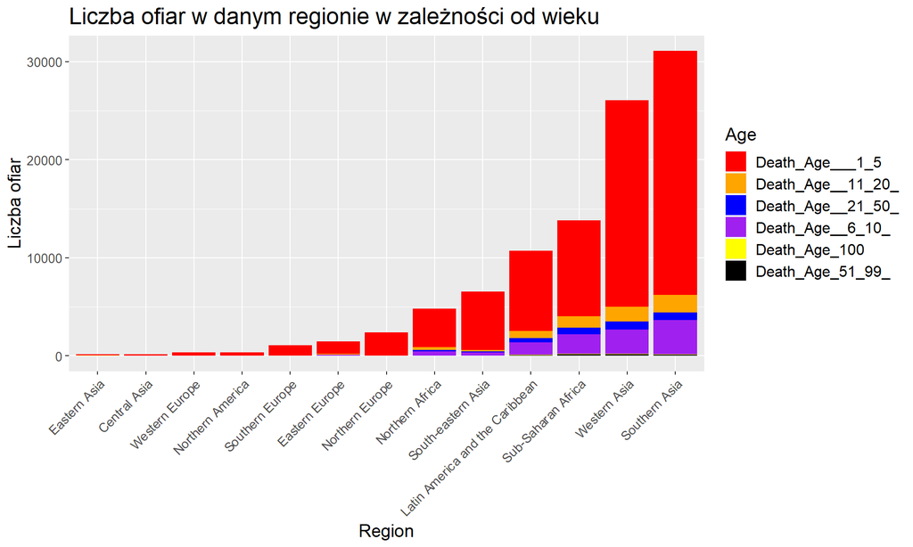

Wykres przedstawia liczbę ofiar w różnych regionach w zależności od wieku. Dane obejmują kategorie wiekowe od 1 do 100 lat, a słupki reprezentują liczbę ofiar w poszczególnych grupach wiekowych. Kolory słupków odpowiadają poszczególnym przedziałom wiekowym.

Regiony takie jak: Eastern Asia(Azja Wschodnia), Central Asia(Azja Środkowa), Western Europe(Europa Zachodnia) i Northem America(Ameryka Północna) charakteryzują się bardzo niską liczbą ofiar, jedynie ofiary te są w przedziale wiekowym od 1-5 lat.

W Latin America and the Caribbean(Ameryka Łacińska i Karaiby) i Sub-Saharan Africa(Afryka Subsaharyjska) przeważa liczba ofiar w wieku od 1-5 lat, mniejszy udział w ogólnej liczbie ofiar mają dzieci w wieku 6-10 lat, następnie osoby w wieku 11-20 lat, a najmniejszy mają osoby w przedziale wiekowym od 21-50. W przypadku Sub-Saharan Africa można zauważyć bardzo niską liczbę ofiar w wieku 51-99 jak i w wieku 100 lat.

Największą liczbą ofiar wyróżniają się dwa regiony: Western Asia(Azja Zachodnia) i Southern Asia(Azja Południowa). Te dwa regiony charakteryzują się największą liczbą ofiar śmiertelnych dzieci w wieku od 1-5 lat, mniej jest ofiar w wieku 6-10 lat, ofiary w wieku 11-20 również mają mały udział w ogólnej liczbie ofiar, a najmniejszy udział mają ofiary w wieku 21-50 nie wliczając w to bardzo małej ilości ofiar w wieku 51-99, która utrzymuje się na poziomie i jest bliska 0.

**Wnioski:**

1.Istnieją istotne różnice w liczbie ofiar między regionami.

2.We wszystkich regionach dominują ofiary w przedziale wiekowym od 1 do 5 lat.

3.Niektóre regiony, takie jak Western Asia(Azja Zachodnia) i Southern Asia(Azja Południowa), charakteryzują się wyjątkowo wysoką liczbą ofiar w tej grupie wiekowej.

4.Eastern Europe wyróżnia się niższą liczbą ofiar w wieku 21-50 lat, co może być rezultatem specyficznych warunków tego obszaru.

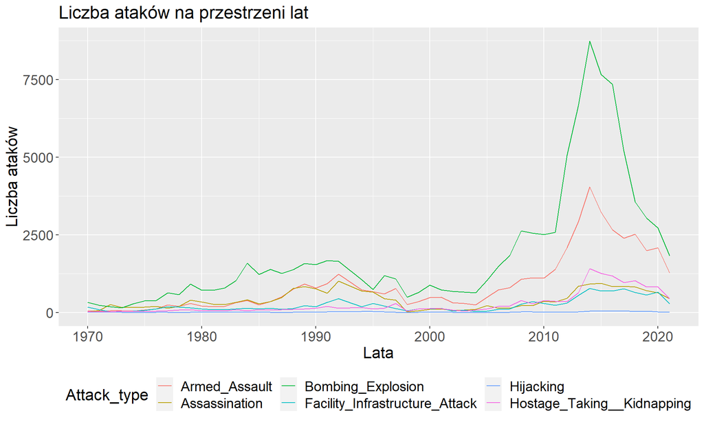

Wykres przedstawia liczbę ataków terrorystycznych na przestrzeni lat, z podziałem na różne metody ataku. Analiza obejmuje lata od 1970 do 2021.

Metoda Bombing Explosion(eksplozja bombowa) wykazuje wyraźną tendencję wzrostową, osiągając swoje apogeum w 2014 roku. W 2014 roku liczba ataków tego typu osiągnęła najwyższą wartość na wykresie, sugerując koncentrację tego rodzaju działań terrorystycznych w tamtym okresie. Należy zauważyć, że od tego czasu metoda ta wykazuje tendencję spadkową, co może być rezultatem skuteczniejszych działań antyterrorystycznych lub zmian w taktykach terrorystycznych.

Podobnie jak Bombing Explosion, metoda Armed Assault (napaść z bronią w ręku) miała swoje maksimum w 2014 roku, co wskazuje na rosnącą aktywność terrorystyczną tego typu w tamtym okresie. Jednak liczba ataków tego rodzaju wykazuje wyraźną tendencję spadkową od 2014 roku, co może świadczyć o zmniejszeniu się skali tego rodzaju działań lub skuteczniejszych działaniach antyterrorystycznych.

Obie metody: Hostage,Taking,Kidnapping i Facility Infrastructure Attack (uprowadzenie i atak na infrastrukturę obiektu), wykazywały tendencję wzrostową do 2014 roku, osiągając apogeum, po czym nastąpił spadek liczby ataków.

Metoda Hijacking (porwanie środka transportu) przez cały okres 1970-2021 utrzymywała się na bardzo niskim poziomie w porównaniu do innych metod.

**Wnioski:**

**1)Zmienność w czasie:**

W analizowanym okresie, zwłaszcza w 2014 roku, obserwujemy dynamiczne zmiany w liczbie ataków terrorystycznych. Skoncentrowane w czasie wzrosty i spadki sugerują, że skuteczność działań antyterrorystycznych oraz ewolucja taktyk terrorystycznych mogą znacząco wpływać na dynamikę ataków.

**2)Rozmaitość metod:**

Zróżnicowanie metod ataków wskazuje na elastyczność i złożoność działań terrorystycznych. Tendencje różnych metod mogą wynikać z dostępności środków, taktyk organizacji terrorystycznych czy reakcji społeczności międzynarodowej.

**3)Wyjątkowa rola roku 2014:**

Rok 2014 wydaje się kluczowy dla wielu metod ataków, co może być rezultatem zmian w globalnym krajobrazie politycznym lub innym czynnikiem wpływającym na dynamikę terroryzmu.

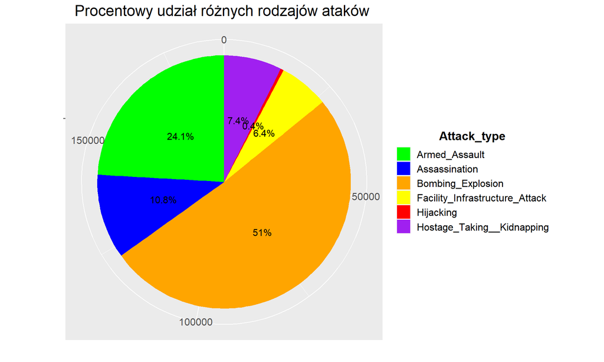

Na wykresie kołowym przedstawiającym procentowy udział różnych rodzajów ataków terrorystycznych możemy zauważyć dominację pewnych metod, co dostarcza istotnych informacji na temat preferencji i strategii terrorystów.

Najczęstszą metodą ataków jest wykorzystanie bomb i eksplozji (51% udziału), co sugeruje skłonność do używania tego typu skutecznych, lecz niebezpiecznych środków.

Drugie miejsce zajmuje atak uzbrojony (24,1%), co wskazuje na wykorzystywanie broni palnej i bezpośrednich konfrontacji jako skutecznej strategii osiągania celów.

Metoda zamachów i zabójstw (10,8%) stanowi znaczący odsetek, co sugeruje, że terroryści preferują ukierunkowane i planowane działania.

Ataki związane z porwaniami i uprowadzeniami (7,4%) są kolejną istotną taktyką, wskazując na gotowość do stosowania tego rodzaju działań wymuszających.

Ataki na obiekty infrastrukturalne (6,4%) stanowią mniejszy, lecz istotny odsetek, co może wiązać się z planowaniem ataków na ważne struktury.

Najrzadszym rodzajem ataku jest porwanie środka transportu (0,4%), co mimo niewielkiego odsetka może prowadzić do sytuacji o wysokim ryzyku.

Podsumowując, analiza procentowego udziału różnych metod ataków dostarcza ważnych wskazówek dla służb antyterrorystycznych, umożliwiając dostosowanie strategii przeciwdziałania do najbardziej dominujących zagrożeń.

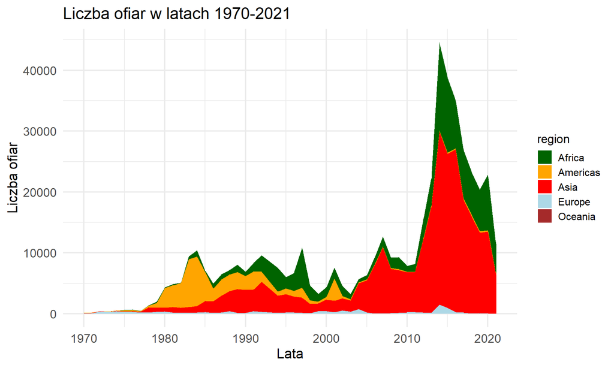

W Europie od początku lat 70 XX wieku liczba ofiar ataków terrorystycznych utrzymuje się na niskim poziomie, minimalny wzrost liczby ofiar można zauważyć w okolicach roku 2014.

Na wykresie nie ma przedstawionych danych dotyczących Oceanii, ponieważ liczba ofiar ataków terrorystycznych jest bliska 0.

W Azji od 1970 do 1993 roku widać znaczącą niewielką tendecję wzrostową, od 1993 nastąpił spadek liczby ofiar do roku około 2003, po tym roku nastąpił wzrost, a po roku około 2012 wystąpił gwałtowny wzrost, który swoje apogeum osiągnął w roku 2014.

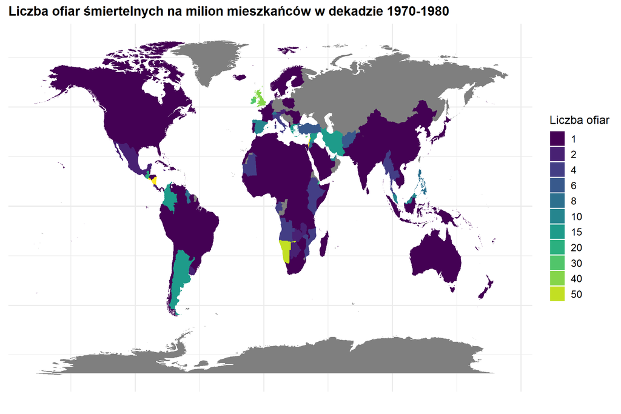

Mapa ukazuje zróżnicowanie liczby zgonów na milion mieszkańców w latach 1970-1980 związanych z aktami terroryzmu na skalę światową. Większość krajów prezentuje niskie lub bardzo niskie wartości, co odzwierciedla względną stabilność w tym okresie. Niemniej jednak, warto zwrócić uwagę na obszary, które wyróżniają się wysokimi wskaźnikami ofiar.

Najważniejsze obszary obejmują Amerykę Łacińską, gdzie Argentyna i Kolumbia doświadczyły wyraźnego wzrostu liczby ofiar na milion mieszkańców, co wskazuje na intensywność działań terrorystycznych w tych regionach. Bliski Wschód, a szczególnie Iran, również prezentuje znaczący wpływ terroryzmu na liczbę zgonów.

W Europie, pomimo ogólnej tendencji do niskich wartości, Wielka Brytania i Hiszpania wyróżniają się wyższą liczbą ofiar, co może być wynikiem działań terrorystycznych w tamtym okresie. Również w Afryce, Namibia charakteryzuje się nietypowo wysokim wskaźnikiem ofiar na milion mieszkańców, co sugeruje specyficzne wydarzenia lub konflikty w regionie.

Ameryka Środkowa, a zwłaszcza Nikaragua, jest kolejnym obszarem wartym uwagi, charakteryzującym się jedną z najwyższych liczb ofiar. Państwa, dla których nie były dostępne dane, takie jak ZSRR, NRD, Mongolia czy Oman, zostały zaznaczone na szaro na mapie z powodu braku informacji.

Analiza tej mapy pozwala zidentyfikować obszary o różnej dynamice w zakresie aktów terrorystycznych, wskazując na specyficzne konteksty społeczno-polityczne, które mogły wpłynąć na poziom zagrożenia i liczbę ofiar w poszczególnych regionach.

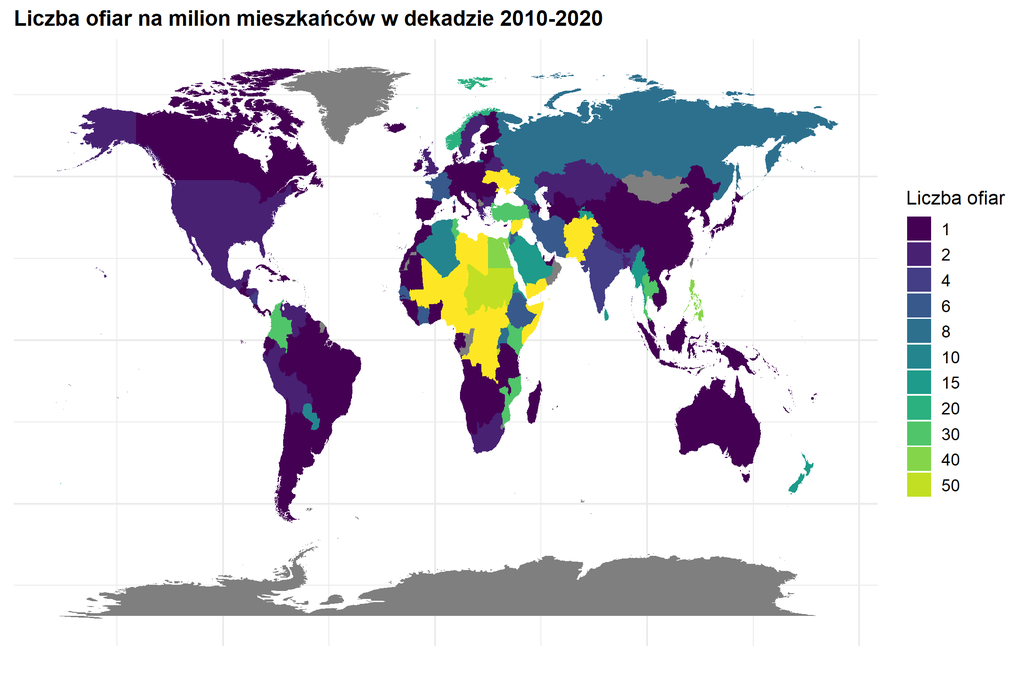

Mapa prezentuje zmieniony krajobraz liczby zgonów na milion mieszkańców w latach 2010-2020 związanych z aktami terroryzmu. W porównaniu do wcześniejszego okresu, obserwujemy nowe trendy, szczególnie w kontekście różnych regionów świata.

**Europa, Ameryka i Australia:** Europa, Ameryka i Australia nadal utrzymują niską liczbę ofiar na milion mieszkańców, co może świadczyć o skutecznych środkach bezpieczeństwa i kontroli.

**Afryka:** W Afryce obserwujemy drastyczną zmianę. Państwa Afryki Środkowej doświadczają bardzo wysokiej liczby ofiar, podczas gdy Południowa i Północno-Zachodnia Afryka utrzymują stosunkowo niskie wskaźniki.

**Zmiany w Innych Regionach:** Ciekawym zjawiskiem jest znaczny wzrost liczby ofiar na Nowej Zelandii i Filipinach. Jednocześnie na Ukrainie, w Pakistanie, Uzbekistanie i Jemenie zaobserwowano znaczący wzrost liczby zabitych, co może odzwierciedlać zmieniający się kontekst polityczny i społeczny w tych regionach.

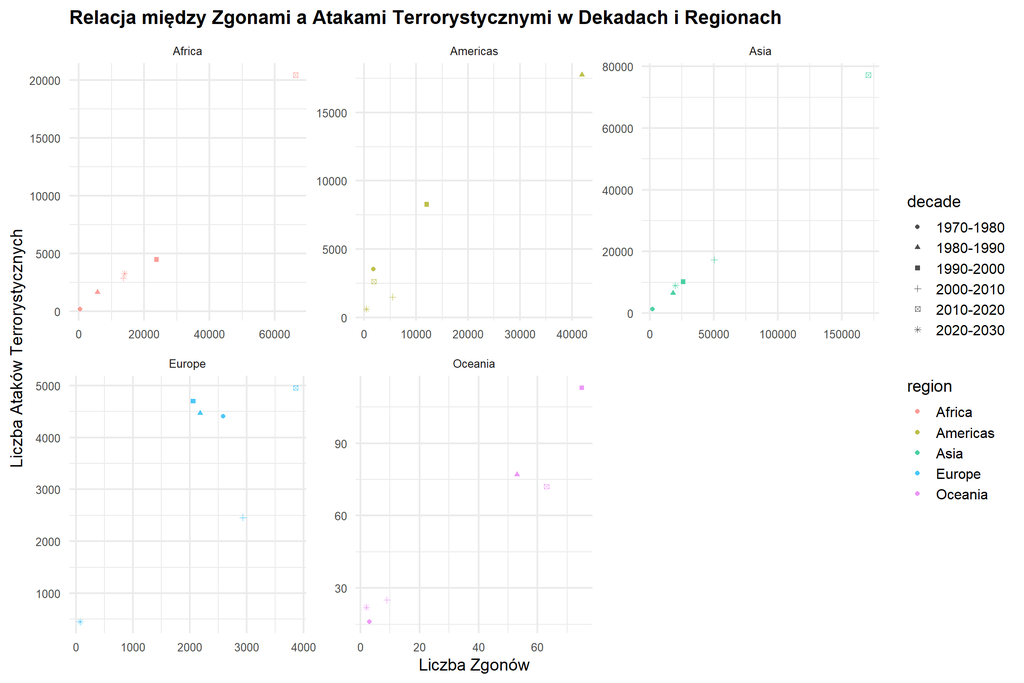

Wykres przedstawia relację między liczbą zgonów a liczbą ataków terrorystycznych w różnych dekadach i regionach świata, wykorzystując scatter plot podzielony na pięć paneli.

Afryka: Największa relacja między liczbą zgonów a liczbą ataków terrorystycznych wystąpiła w dekadzie 2010-2020, osiągając wysokie wartości, podczas gdy najmniejsza relacja była obserwowana w latach 1970-1980.

Azja: Najwyższa relacja między zgonami a liczbą ataków występowała w dekadzie 2010-2020, co może wynikać z różnorodności geograficznej i społecznej tego obszaru. Wzrost zarówno w liczbie ataków, jak i zgonów, jest zauważalny w porównaniu do lat 70. XX wieku.

Europa: Największa relacja między liczbą zgonów a liczbą ataków przypada na dekadę 2010-2020, sugerując znaczny wzrost skali i skutków ataków terrorystycznych w ostatnich latach.

Oceania: Relacja między liczbą zgonów a liczbą ataków osiągała najwyższe wartości w dekadzie 1990-2000, co może być związane z pewnymi specyficznymi wydarzeniami na tym obszarze w tym okresie.

**Wnioski:** W większości regionów, relacja między zgonami a atakami terrorystycznymi rośnie wraz z upływem czasu, zwłaszcza w najnowszych dekadach. Sugeruje to zwiększającą się skalę i skutki ataków terrorystycznych, co stanowi wyzwanie dla działań mających na celu ich zapobieganie i zwalczanie.

6)Podsumowanie

Projekt analizy ataków terrorystycznych w latach 1970-2021 przyniósł interesujące spostrzeżenia na temat dynamiki i wzorców tego zjawiska na różnych kontynentach i w różnych okresach czasu. Zastosowanie różnych analiz przestrzennych i tematycznych pozwoliło lepiej zrozumieć specyfikę ataków terrorystycznych oraz ich wpływ na społeczeństwa na całym świecie.

W powyższej analizie można było zauważyć, że między innymi liczba ataków, jak i liczba ofiar była znacząco wyższa w 2014 roku, było to spowodowane m.in.:

Syria i konflikty w regionie Bliskiego Wschodu: W 2014 roku trwała wojna domowa w Syrii, która przyciągnęła uwagę międzynarodową. Sytuacja ta mogła sprzyjać aktywności terrorystycznej i wzrostowi liczby ataków.

Działania ISIS: W 2014 roku Państwo Islamskie (ISIS) zdobyło znaczną uwagę światową, ogłaszając utworzenie kalifatu. Organizacja ta przeprowadzała liczne ataki terrorystyczne w Iraku, Syrii i innych regionach, co mogło wpłynąć na globalne statystyki ataków.

Zmieniający się krajobraz polityczny: W latach 2014-2015 miały miejsce różne wydarzenia polityczne, takie jak zmiana władzy w Iraku, konflikt wewnętrzny na Ukrainie czy wzrost aktywności talibów w Afganistanie. Te zdarzenia mogły przyczynić się do zwiększenia liczby ataków terrorystycznych.

Wpływ mediów społecznościowych: Wzrost dostępności mediów społecznościowych i ich rola w komunikacji globalnej mogły sprawić, że ataki terrorystyczne stały się bardziej widoczne i szybko się rozprzestrzeniały, co mogło wpłynąć na zwiększenie raportowanych przypadków.

Złożoność terroryzmu globalnego: Terroryzm jest zjawiskiem złożonym, a liczba ataków zależy od wielu czynników, takich jak konflikty regionalne, nierówności społeczne, skrajne ideologie czy działania grup ekstremistycznych. Wzrost liczby ataków w 2014 roku może być wynikiem skomplikowanego zestawu czynników.

**Wnioski:**

Zróżnicowanie regionalne: Analiza liczby ataków i ofiar w poszczególnych regionach wykazała istotne zróżnicowanie. Niektóre obszary, takie jak Azja Południowa i Zachodnia, czy Bliski Wschód, doświadczyły znaczących wzrostów liczby ofiar, podczas gdy inne, jak Europa, utrzymywały stosunkowo niskie poziomy.

Tendencje czasowe: Wzrost liczby ataków terrorystycznych w latach 2010-2021, zwłaszcza w Afryce, stanowi istotny trend. Spadek liczby ofiar w regionie Europy w ostatnich latach może być wynikiem skuteczniejszych środków bezpieczeństwa.

Różnice wiekowe: Analiza wieku ofiar pozwoliła zidentyfikować obszary, gdzie dzieci są szczególnie narażone, jak Southern Asia(Azja Południowa) czy Western Asia(Azja Zachodnia). To ważne spostrzeżenie dla działań prewencyjnych i ochrony najbardziej podatnych grup społecznych.

Metody ataków: Wykres procentowego udziału różnych metod ataków pokazał, że bombowanie i eksplozje dominują, co sugeruje skłonność terrorystów do stosowania skutecznych, lecz niebezpiecznych środków.

Relacja między zgonami a atakami: Analiza scatter plot dla różnych dekad i regionów ukazała, że relacja między liczbą zgonów a atakami rośnie wraz z upływem czasu, co może świadczyć o zwiększającym się wpływie ataków terrorystycznych na społeczeństwo.